# P1: TMDb Movie Data

@by Hua 2020.05.04

## Introduction

- Data : [TMDb movie data](https://www.kaggle.com/tmdb/tmdb-movie-metadata) (Kaggle)
- Description: Two data sets contain information about 5000 movies (1916 - 2017) collected from The Movie Database (TMDb), one is called `movie` including user ratings and revenue, another one is `credit` including cast and crew information.
- Priori questions to explore:
  1. Overall distribution and correlation of quantitive variables.
  2. The percentage of quantitive variables with time, e.g., # of films, revenue.
  3. The percentage of categorical variables, e.g., country, genres and language.
  4. The variation of variables with time.
  5. The relation within multiple variables.
  6. Extract the Top 100 (ordered by revenue/budget) films for other exploration.

```python
# Import the neccessary modules and option settings.

import numpy as np
import matplotlib.pyplot as plt
import seaborn as sb
import pandas as pd
import statsmodels.api as sm
import json, sys, zipfile, warnings
from matplotlib import cm
warnings.filterwarnings('ignore')
%matplotlib inline
# from IPython.core.interactiveshell import InteractiveShell
# InteractiveShell.ast_node_interactivity = "all"

np.set_printoptions(threshold=sys.maxsize)
pd.set_option('display.max_columns', 500)
pd.set_option('display.max_rows', 50)
```

```python
# # unzip file
# with zipfile.ZipFile('./data/tmdb-movie-metadata.zip','r') as myzip:
#     myzip.extractall('./data')
```

```python
# read data
movie=pd.read_csv('./data/tmdb_5000_movies.csv')
credit=pd.read_csv('./data/tmdb_5000_credits.csv')
```

## Data Wrangling

### Tidiness

1. Load Json datatype in `movie` and `credit` dataset
2. Check if two dataset are uniquely corresponding and then apply intersect merge
3. Deal with the Json columns and split the contents
4. Change `release_date` column to datetime style, split the year and group to decade
5. Make the columns head consistent in lower case, and then reorder and remove the unneccessary columns

### Quality

1. Clean missing and unreasonable value in `revenue`, `budget` and `vote_count` to help the following analysis. Then define a `ratio = revenue / budget` criterion to represent the **successful** film for earning money

#### 1. Load Json datatype in `movie` and `credit` dataset

The Json style in two datasets needs to be decomposed:

- movie : genres, keywords, production_countries, production_companies, spken_language
- credit : cast, crew

```python
movie_json_column=['genres','keywords','production_countries','production_companies',
                   'spoken_languages']
credit_json_column=['cast','crew']
for i in movie_json_column:
    movie[i]=movie[i].apply(json.loads)
for i in credit_json_column:
    credit[i]=credit[i].apply(json.loads)
```

```python
movie.head(1)
```

|  | budget | genres | homepage | id | keywords | original_language | original_title | overview | popularity | production_companies | production_countries | release_date | revenue | runtime | spoken_languages | status | tagline | title | vote_average | vote_count |
| --- | --- | --- | --- | --- | --- | --- | --- | --- | --- | --- | --- | --- | --- | --- | --- | --- | --- | --- | --- | --- |
| 0 | 237000000 | [{'id': 28, 'name': 'Action'}, {'id': 12, 'nam... | http://www.avatarmovie.com/ | 19995 | [{'id': 1463, 'name': 'culture clash'}, {'id':... | en | Avatar | In the 22nd century, a paraplegic Marine is di... | 150.437577 | [{'name': 'Ingenious Film Partners', 'id': 289... | [{'iso_3166_1': 'US', 'name': 'United States o... | 2009-12-10 | 2787965087 | 162.0 | [{'iso_639_1': 'en', 'name': 'English'}, {'iso... | Released | Enter the World of Pandora. | Avatar | 7.2 | 11800 |

```python
credit.head(1)
```

|  | movie_id | title | cast | crew |
| --- | --- | --- | --- | --- |
| 0 | 19995 | Avatar | [{'cast_id': 242, 'character': 'Jake Sully', '... | [{'credit_id': '52fe48009251416c750aca23', 'de... |

#### 2. Check if two dataset are uniquely corresponding and then merge

These two datasets both have 4803 non-null (movie) ids, thus I have to first check if these two datasets have same movies, and then combine them together.

**Note**: Although I do not really take the exploration of the cast and crew information in this study, it is still a great opportunity to practice the decompositional skills of Json-style. Thus, I will stil clean these variables in the following.

```python
# check the null number of these two datasets
movie.id.count(), movie.id.isnull().sum(),credit.movie_id.count(),credit.movie_id.isnull().sum()
```

```
(4803, 0, 4803, 0)
```

```python
# check if their movie_id numbers are the same
sum(movie.id.sort_values() == credit.movie_id.sort_values())
```

```
4803
```

```python
# apply intersect merge
df=pd.merge(movie,credit,left_on='id',right_on='movie_id')
df.drop(['movie_id'],axis=1,inplace=True)
```

```python
df.head(1)
```

|  | budget | genres | homepage | id | keywords | original_language | original_title | overview | popularity | production_companies | production_countries | release_date | revenue | runtime | spoken_languages | status | tagline | title_x | vote_average | vote_count | title_y | cast | crew |
| --- | --- | --- | --- | --- | --- | --- | --- | --- | --- | --- | --- | --- | --- | --- | --- | --- | --- | --- | --- | --- | --- | --- | --- |
| 0 | 237000000 | [{'id': 28, 'name': 'Action'}, {'id': 12, 'nam... | http://www.avatarmovie.com/ | 19995 | [{'id': 1463, 'name': 'culture clash'}, {'id':... | en | Avatar | In the 22nd century, a paraplegic Marine is di... | 150.437577 | [{'name': 'Ingenious Film Partners', 'id': 289... | [{'iso_3166_1': 'US', 'name': 'United States o... | 2009-12-10 | 2787965087 | 162.0 | [{'iso_639_1': 'en', 'name': 'English'}, {'iso... | Released | Enter the World of Pandora. | Avatar | 7.2 | 11800 | Avatar | [{'cast_id': 242, 'character': 'Jake Sully', '... | [{'credit_id': '52fe48009251416c750aca23', 'de... |

#### 3. Deal with the Json columns and split the contents

#### Rule:

I take first few terms to see the main contribution and avoid too many nan values.

- **company, country, director, producer, writer** : Take the first name
- **casts** : Take the first three names
- **crews** : Take the first name of Director, Writer and Producer
- **spoken_language** : Ignored, because the **original_language** might be enough for me
- **genres** : Split by | and generate all the individual columns
- **keywords** : Split by |

```python
# learn from Ref(1) that a good way to extract what I want in json style
def safe_access(container, index_values):
    # return missing value rather than an error upon indexing/key failure
    result = container
    try:
        for idx in index_values:
            result = result[idx]
        return result
    except IndexError or KeyError:
        return pd.np.nan

def get_dir(crew_data):
    gj = [x['name'] for x in crew_data if x['job'] == 'Director']
    return safe_access(gj, [0])

def get_writer(crew_data):
    gj = [x['name'] for x in crew_data if x['job'] == 'Writer']
    return safe_access(gj, [0])

def get_producer(crew_data):
    gj = [x['name'] for x in crew_data if x['job'] == 'Producer']
    return safe_access(gj, [0])

def pipe_split(column):
    return '|'.join([x['name'] for x in column])

def unique_set_list(column):
    # find unique list of the items
    uni_list=set()
    for each_row in df[column].str.split('|').values:
        if isinstance(each_row,float): continue # avoid word = NaN
        uni_list=uni_list.union(each_row)
#     uni_list.remove('')
    return uni_list
```

```python
# add new columns
df['country']=df.production_countries.apply(lambda x: safe_access(x, [0, 'name']))
df['company']=df.production_companies.apply(lambda x: safe_access(x, [0, 'name']))
df['director']=df['crew'].apply(get_dir)
df['producer']=df['crew'].apply(get_producer)
df['writer']=df['crew'].apply(get_writer)

df['actor1']=df['cast'].apply(lambda x: safe_access(x, [0, 'name']))
df['actor2']=df['cast'].apply(lambda x: safe_access(x, [1, 'name']))
df['actor3']=df['cast'].apply(lambda x: safe_access(x, [2, 'name']))

df['keywords_split']=df['keywords'].apply(pipe_split)
df['genres_split']=df['genres'].apply(pipe_split)

genres_list=list(unique_set_list('genres_split'))
keywords_list=unique_set_list('keywords_split')

df.head(1)
```

|  | budget | genres | homepage | id | keywords | original_language | original_title | overview | popularity | production_companies | production_countries | release_date | revenue | runtime | spoken_languages | status | tagline | title_x | vote_average | vote_count | title_y | cast | crew | country | company | director | producer | writer | actor1 | … |
| --- | --- | --- | --- | --- | --- | --- | --- | --- | --- | --- | --- | --- | --- | --- | --- | --- | --- | --- | --- | --- | --- | --- | --- | --- | --- | --- | --- | --- | --- | --- |
| 0 | 237000000 | [{'id': 28, 'name': 'Action'}, {'id': 12, 'nam... | http://www.avatarmovie.com/ | 19995 | [{'id': 1463, 'name': 'culture clash'}, {'id':... | en | Avatar | In the 22nd century, a paraplegic Marine is di... | 150.437577 | [{'name': 'Ingenious Film Partners', 'id': 289... | [{'iso_3166_1': 'US', 'name': 'United States o... | 2009-12-10 | 2787965087 | 162.0 | [{'iso_639_1': 'en', 'name': 'English'}, {'iso... | Released | Enter the World of Pandora. | Avatar | 7.2 | 11800 | Avatar | [{'cast_id': 242, 'character': 'Jake Sully', '... | [{'credit_id': '52fe48009251416c750aca23', 'de... | United States of America | Ingenious Film Partners | James Cameron | James Cameron | James Cameron | Sam Worthington | … |

```python
# generate every genres columns with zero-value
df[genres_list]=pd.DataFrame([np.zeros((len(genres_list)))],index=df.index)
df.head(1)
```

|  | budget | genres | homepage | id | keywords | original_language | original_title | overview | popularity | production_companies | production_countries | release_date | revenue | runtime | spoken_languages | status | tagline | title_x | vote_average | vote_count | title_y | cast | crew | country | company | director | producer | writer | actor1 | … |
| --- | --- | --- | --- | --- | --- | --- | --- | --- | --- | --- | --- | --- | --- | --- | --- | --- | --- | --- | --- | --- | --- | --- | --- | --- | --- | --- | --- | --- | --- | --- |
| 0 | 237000000 | [{'id': 28, 'name': 'Action'}, {'id': 12, 'nam... | http://www.avatarmovie.com/ | 19995 | [{'id': 1463, 'name': 'culture clash'}, {'id':... | en | Avatar | In the 22nd century, a paraplegic Marine is di... | 150.437577 | [{'name': 'Ingenious Film Partners', 'id': 289... | [{'iso_3166_1': 'US', 'name': 'United States o... | 2009-12-10 | 2787965087 | 162.0 | [{'iso_639_1': 'en', 'name': 'English'}, {'iso... | Released | Enter the World of Pandora. | Avatar | 7.2 | 11800 | Avatar | [{'cast_id': 242, 'character': 'Jake Sully', '... | [{'credit_id': '52fe48009251416c750aca23', 'de... | United States of America | Ingenious Film Partners | James Cameron | James Cameron | James Cameron | Sam Worthington | … |

```python
# give values of every genres
for idx,each_row in enumerate(df['genres_split'].str.split('|').values):
    if isinstance(each_row,float): continue # avoid word = NaN
    df.loc[idx,each_row]=1
```

```python
df.head(1)
```

|  | budget | genres | homepage | id | keywords | original_language | original_title | overview | popularity | production_companies | production_countries | release_date | revenue | runtime | spoken_languages | status | tagline | title_x | vote_average | vote_count | title_y | cast | crew | country | company | director | producer | writer | actor1 | … |
| --- | --- | --- | --- | --- | --- | --- | --- | --- | --- | --- | --- | --- | --- | --- | --- | --- | --- | --- | --- | --- | --- | --- | --- | --- | --- | --- | --- | --- | --- | --- |
| 0 | 237000000 | [{'id': 28, 'name': 'Action'}, {'id': 12, 'nam... | http://www.avatarmovie.com/ | 19995 | [{'id': 1463, 'name': 'culture clash'}, {'id':... | en | Avatar | In the 22nd century, a paraplegic Marine is di... | 150.437577 | [{'name': 'Ingenious Film Partners', 'id': 289... | [{'iso_3166_1': 'US', 'name': 'United States o... | 2009-12-10 | 2787965087 | 162.0 | [{'iso_639_1': 'en', 'name': 'English'}, {'iso... | Released | Enter the World of Pandora. | Avatar | 7.2 | 11800 | Avatar | [{'cast_id': 242, 'character': 'Jake Sully', '... | [{'credit_id': '52fe48009251416c750aca23', 'de... | United States of America | Ingenious Film Partners | James Cameron | James Cameron | James Cameron | Sam Worthington | … |

#### 4. Deal with the `release_date` column

- Change to datetime style
- Split and extract the year
- Check that the nan row hardly provides any information, thus remove it
- Change to int style
- Group the almost 120-year sapn to 10-year decage, which will make the following visualization more convenient

```python
# Change to datetime style
df['year']=pd.to_datetime(df['release_date']).apply(lambda x: x.year)
```

```python
# check nan row and change to int style
df.drop(df[df.year.isnull()].index,inplace=True)
df.year=df.year.astype(int)
```

```python
# group to decade
df['decade']=df['year'].apply(lambda x: ((x-1900)//10)*10).astype(int)
```

```python
df.head(1)
```

|  | budget | genres | homepage | id | keywords | original_language | original_title | overview | popularity | production_companies | production_countries | release_date | revenue | runtime | spoken_languages | status | tagline | title_x | vote_average | vote_count | title_y | cast | crew | country | company | director | producer | writer | actor1 | … |
| --- | --- | --- | --- | --- | --- | --- | --- | --- | --- | --- | --- | --- | --- | --- | --- | --- | --- | --- | --- | --- | --- | --- | --- | --- | --- | --- | --- | --- | --- | --- |
| 0 | 237000000 | [{'id': 28, 'name': 'Action'}, {'id': 12, 'nam... | http://www.avatarmovie.com/ | 19995 | [{'id': 1463, 'name': 'culture clash'}, {'id':... | en | Avatar | In the 22nd century, a paraplegic Marine is di... | 150.437577 | [{'name': 'Ingenious Film Partners', 'id': 289... | [{'iso_3166_1': 'US', 'name': 'United States o... | 2009-12-10 | 2787965087 | 162.0 | [{'iso_639_1': 'en', 'name': 'English'}, {'iso... | Released | Enter the World of Pandora. | Avatar | 7.2 | 11800 | Avatar | [{'cast_id': 242, 'character': 'Jake Sully', '... | [{'credit_id': '52fe48009251416c750aca23', 'de... | United States of America | Ingenious Film Partners | James Cameron | James Cameron | James Cameron | Sam Worthington | … |

#### 5. Deal with the table head

- Remove:genres, homepage, keywords, production_countries, production_companies, spoken_languages, cast, crew, title_x, title_y, release_date
- Change each genres to lower case
- Rename:

  ```
      original_language -> language
      original_title    -> title
      keywords_split    -> keywords
      genres_split      -> genres
  ```

- Rearrange the order for the comfortable looks

```python
# Remove unneccessary columns
dn=df.drop(['genres','homepage','keywords','production_countries','production_companies','spoken_languages','cast',
            'crew','title_x','title_y','release_date',''],axis=1)
```

```python
# clean the head and rename
dn.rename(columns=lambda x: x.strip().lower().replace(" ", "_"), inplace=True)
Rename_all={
    'original_language': 'language',
    'original_title': 'title',
    'keywords_split': 'keywords',
    'genres_split': 'genres',
    }
dn.rename(columns=Rename_all, inplace=True)
```

```python
dn.head(1)
```

|  | budget | id | language | title | overview | popularity | revenue | runtime | status | tagline | vote_average | vote_count | country | company | director | producer | writer | actor1 | actor2 | actor3 | keywords | genres | comedy | fantasy | tv_movie | crime | horror | foreign | western | … |
| --- | --- | --- | --- | --- | --- | --- | --- | --- | --- | --- | --- | --- | --- | --- | --- | --- | --- | --- | --- | --- | --- | --- | --- | --- | --- | --- | --- | --- | --- | --- |
| 0 | 237000000 | 19995 | en | Avatar | In the 22nd century, a paraplegic Marine is di... | 150.437577 | 2787965087 | 162.0 | Released | Enter the World of Pandora. | 7.2 | 11800 | United States of America | Ingenious Film Partners | James Cameron | James Cameron | James Cameron | Sam Worthington | Zoe Saldana | Sigourney Weaver | culture clash\|future\|space war\|space colony\|so... | Action\|Adventure\|Fantasy\|Science Fiction | 0.0 | 1.0 | 0.0 | 0.0 | 0.0 | 0.0 | 0.0 | … |

```python
# change the head order
dn=dn[['id','title','language','year', 'decade','budget','revenue', 'runtime','vote_average',
      'popularity','vote_count','crime', 'comedy','adventure', 'action', 'romance', 'horror',
      'history', 'documentary','mystery', 'fantasy', 'war', 'family', 'animation', 'drama',
      'science_fiction', 'tv_movie', 'music', 'thriller', 'foreign','western','keywords',
      'genres','status', 'overview','tagline', 'country', 'company', 'director', 'producer',
      'writer', 'actor1','actor2', 'actor3']]
```

```python
dn.tail(1)
```

|  | id | title | language | year | decade | budget | revenue | runtime | vote_average | popularity | vote_count | crime | comedy | adventure | action | romance | horror | history | documentary | mystery | fantasy | war | family | animation | drama | science_fiction | tv_movie | music | thriller | … |
| --- | --- | --- | --- | --- | --- | --- | --- | --- | --- | --- | --- | --- | --- | --- | --- | --- | --- | --- | --- | --- | --- | --- | --- | --- | --- | --- | --- | --- | --- | --- |
| 4802 | 25975 | My Date with Drew | en | 2005 | 100 | 0 | 0 | 90.0 | 6.3 | 1.929883 | 16 | 0.0 | 0.0 | 0.0 | 0.0 | 0.0 | 0.0 | 0.0 | 1.0 | 0.0 | 0.0 | 0.0 | 0.0 | 0.0 | 0.0 | 0.0 | 0.0 | 0.0 | 0.0 | … |

#### 6. Clean missing and unreasonable value in `revenue` , `budget`, `vote_count` to help the following analysis

- Define a new variable: **ratio = revenue / budget**

  Although I can directly compare other variables with revenue to explore the **successful** property of the films, the higher revenue should not be the successful one if its budget is high also. Thus, I define a **ratio** variable that can be another criterion to examine whether this movie is **successful** for earning money.

  On the other hand, I will compare the relation between the popularity and the vote_average based on the ratio and so on. Therefore, the zero-revenue, small budget (<100 should be wrong record), zero-vote_count will all be removed.

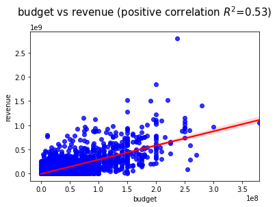

```python
# visulize the correlation between budget and revenue
temp=dn.copy();temp['intercept']=1
lm = sm.OLS(temp['revenue'], temp[['budget', 'intercept']])
results = lm.fit().rsquared
sb.regplot(dn.budget,dn.revenue,scatter_kws={"color": "blue"}, line_kws={"color": "red"});
plt.xlabel('budget');plt.ylabel('revenue')
plt.title('budget vs revenue (positive correlation '+r'$R^2$={:.2f})'.format(results),fontsize=15,y=1.08);
```

```python
# construct dm (Besides budget, revenue and vote_count, we remove one non-value genres )
dm=dn.copy()
dm.drop(dm.query('budget<=100').index,inplace=True)
dm.drop(dm.query('revenue==0').index,inplace=True)
dm.drop(dm.query('vote_count==0').index,inplace=True)
dm.drop(dm.query('genres==""').index,inplace=True) # only one row
```

```python
# generate ratio
dm['ratio']=dm['revenue']/dm['budget']
```

```python
dm[dm.ratio==dm.ratio.max()]
```

|  | id | title | language | year | decade | budget | revenue | runtime | vote_average | popularity | vote_count | crime | comedy | adventure | action | romance | horror | history | documentary | mystery | fantasy | war | family | animation | drama | science_fiction | tv_movie | music | thriller | … |
| --- | --- | --- | --- | --- | --- | --- | --- | --- | --- | --- | --- | --- | --- | --- | --- | --- | --- | --- | --- | --- | --- | --- | --- | --- | --- | --- | --- | --- | --- | --- |
| 4577 | 23827 | Paranormal Activity | en | 2007 | 100 | 15000 | 193355800 | 86.0 | 5.9 | 47.456823 | 1316 | 0.0 | 0.0 | 0.0 | 0.0 | 0.0 | 1.0 | 0.0 | 0.0 | 1.0 | 0.0 | 0.0 | 0.0 | 0.0 | 0.0 | 0.0 | 0.0 | 0.0 | 0.0 | … |

Although the ratio has extremely high value, this case is real (search from google) and would keep in this study.

## Exploratory Data Analysis

#### 1. Overall distribution and correlation of quantitive variables

```python
# reset the index
dm.reset_index(drop=True,inplace=True)
```

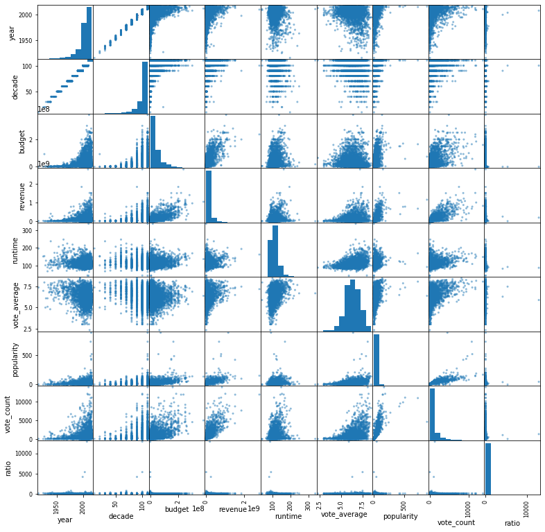

```python
pd.plotting.scatter_matrix(dm.iloc[:,np.r_[1:11,44]],figsize=(13,13));
```

Overview of all the quantative variables.

```python
dm.describe()
```

|  | id | year | decade | budget | revenue | runtime | vote_average | popularity | vote_count | crime | comedy | adventure | action | romance | horror | history | documentary | mystery | fantasy | war | family | animation | drama | science_fiction | tv_movie | music | thriller | foreign | western | … |
| --- | --- | --- | --- | --- | --- | --- | --- | --- | --- | --- | --- | --- | --- | --- | --- | --- | --- | --- | --- | --- | --- | --- | --- | --- | --- | --- | --- | --- | --- | --- |
| count | 3215.000000 | 3215.000000 | 3215.000000 | 3.215000e+03 | 3.215000e+03 | 3215.000000 | 3215.000000 | 3215.000000 | 3215.000000 | 3215.000000 | 3215.000000 | 3215.000000 | 3215.000000 | 3215.000000 | 3215.000000 | 3215.000000 | 3215.00000 | 3215.000000 | 3215.000000 | 3215.000000 | 3215.000000 | 3215.000000 | 3215.000000 | 3215.000000 | 3215.0 | 3215.000000 | 3215.000000 | 3215.000000 | 3215.000000 | … |
| mean | 44615.660964 | 2001.723484 | 97.393468 | 4.082999e+07 | 1.217646e+08 | 110.757387 | 6.313904 | 29.134922 | 981.045723 | 0.161120 | 0.343701 | 0.205288 | 0.284603 | 0.177605 | 0.102333 | 0.045101 | 0.01182 | 0.082426 | 0.106065 | 0.037014 | 0.113219 | 0.058165 | 0.445723 | 0.133748 | 0.0 | 0.034526 | 0.289580 | 0.001244 | 0.017729 | … |
| std | 74337.716592 | 13.186508 | 13.603383 | 4.441334e+07 | 1.865398e+08 | 20.957025 | 0.859782 | 36.208563 | 1416.166953 | 0.367699 | 0.475017 | 0.403975 | 0.451296 | 0.382239 | 0.303133 | 0.207558 | 0.10809 | 0.275056 | 0.307969 | 0.188825 | 0.316910 | 0.234091 | 0.497123 | 0.340434 | 0.0 | 0.182603 | 0.453638 | 0.035256 | 0.131987 | … |
| min | 5.000000 | 1916.000000 | 10.000000 | 2.180000e+02 | 7.000000e+00 | 41.000000 | 2.300000 | 0.019984 | 1.000000 | 0.000000 | 0.000000 | 0.000000 | 0.000000 | 0.000000 | 0.000000 | 0.000000 | 0.00000 | 0.000000 | 0.000000 | 0.000000 | 0.000000 | 0.000000 | 0.000000 | 0.000000 | 0.0 | 0.000000 | 0.000000 | 0.000000 | 0.000000 | … |
| 25% | 4947.500000 | 1998.000000 | 90.000000 | 1.100000e+07 | 1.728331e+07 | 96.000000 | 5.800000 | 10.566302 | 180.000000 | 0.000000 | 0.000000 | 0.000000 | 0.000000 | 0.000000 | 0.000000 | 0.000000 | 0.00000 | 0.000000 | 0.000000 | 0.000000 | 0.000000 | 0.000000 | 0.000000 | 0.000000 | 0.0 | 0.000000 | 0.000000 | 0.000000 | 0.000000 | … |
| 50% | 11426.000000 | 2005.000000 | 100.000000 | 2.500000e+07 | 5.570741e+07 | 107.000000 | 6.300000 | 20.544999 | 476.000000 | 0.000000 | 0.000000 | 0.000000 | 0.000000 | 0.000000 | 0.000000 | 0.000000 | 0.00000 | 0.000000 | 0.000000 | 0.000000 | 0.000000 | 0.000000 | 0.000000 | 0.000000 | 0.0 | 0.000000 | 0.000000 | 0.000000 | 0.000000 | … |
| 75% | 45256.000000 | 2010.000000 | 110.000000 | 5.500000e+07 | 1.471896e+08 | 121.000000 | 6.900000 | 37.415032 | 1149.500000 | 0.000000 | 1.000000 | 0.000000 | 1.000000 | 0.000000 | 0.000000 | 0.000000 | 0.00000 | 0.000000 | 0.000000 | 0.000000 | 0.000000 | 0.000000 | 1.000000 | 0.000000 | 0.0 | 0.000000 | 1.000000 | 0.000000 | 0.000000 | … |
| max | 417859.000000 | 2016.000000 | 110.000000 | 3.800000e+08 | 2.787965e+09 | 338.000000 | 8.500000 | 875.581305 | 13752.000000 | 1.000000 | 1.000000 | 1.000000 | 1.000000 | 1.000000 | 1.000000 | 1.000000 | 1.00000 | 1.000000 | 1.000000 | 1.000000 | 1.000000 | 1.000000 | 1.000000 | 1.000000 | 0.0 | 1.000000 | 1.000000 | 1.000000 | 1.000000 | … |

See the overview of descriptive statistics, but it's better to visulaize some particular features in the following exploration.

#### 2. The percentage of quantitive variables with time

```python
def change_year(df):
    df.index=[str(x+1900) for x in df.index.tolist()]
    return df

def pie_split(ax,df,topn,other_name='others',legend=False):
    pie_df=df.sort_values(ascending=False)
    df1=pie_df[:topn].copy()
    df2=pie_df[topn:].sum()
    df1[other_name]=df2
    cs=cm.Pastel1(np.arange(9)/9.)
    if legend:
        patches, texts, autotexts=ax.pie(df1,autopct='%1.1f%%',colors=cs,startangle=0,
                                     wedgeprops = { "edgecolor" : 'k'},
                                     textprops = {"fontsize" : 15});
        ax.legend(df1.index,bbox_to_anchor=(1.05,0.8),fontsize=15)
    else:
        patches, texts, autotexts=ax.pie(df1,labels=df1.index,autopct='%1.1f%%',colors=cs,startangle=0,
                                     wedgeprops = { "edgecolor" : 'k'},
                                     textprops = {"fontsize" : 15});
    return patches, texts, autotexts,ax
```

```python
# generate a sort_list for genres counts
Genres_df=dm.iloc[:,11:31]
Genres_sort=Genres_df.sum().sort_values(ascending=False)
```

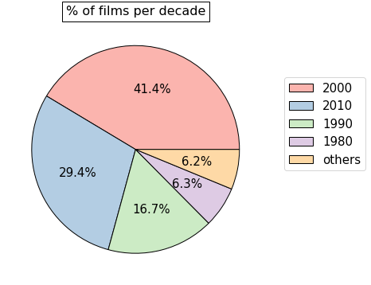

```python
tmpdf=change_year(dm.groupby(dm.decade)['id'].count())
f,ax=plt.subplots(figsize=(6,6),nrows=1, ncols=1)
pie_split(ax,tmpdf,4,legend=True);
plt.title('% of films per decade',bbox={'facecolor':'white','pad':5},fontsize=16);
```

Films in 2000 decade are the most.

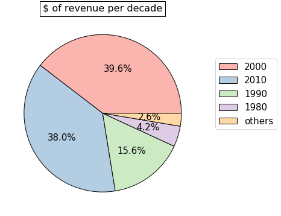

```python
f,ax=plt.subplots(figsize=(6,6),nrows=1, ncols=1)
pie_split(ax,change_year(dm.groupby('decade')['revenue'].sum()),4,legend=True);
ax.set_title('$ of revenue per decade',bbox={'facecolor':'white','pad':5},fontsize=16);
```

The revenue in 2000 and 2010 decades has almost the same percentage.

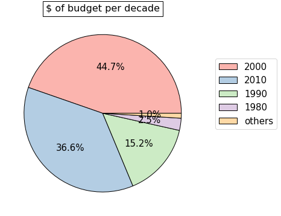

```python
f,ax=plt.subplots(figsize=(6,6),nrows=1, ncols=1)
pie_split(ax,change_year(dm.groupby('decade')['budget'].sum()),4,legend=True);
ax.set_title('$ of budget per decade',bbox={'facecolor':'white','pad':5},fontsize=16);
```

Budget in 2000 decade is the most.

Interesting observation:

- Although 2000 decade has more films, the overall revenue are almost equivalent in 2000 and 2010 decades.

#### 3. The percentage of categorical variables

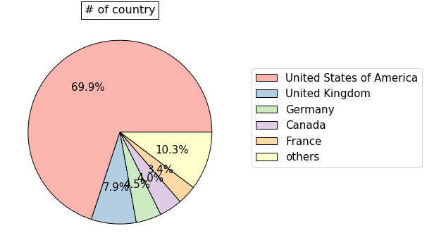

```python
f,ax=plt.subplots(figsize=(6,6),nrows=1, ncols=1)
pie_split(ax,dm.groupby('country').count().id,5,legend=True);
ax.set_title('# of country',bbox={'facecolor':'white','pad':5},fontsize=16);
```

Films produced in the United States of America are the most.

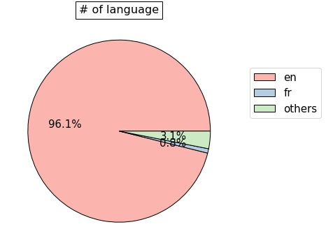

```python
f,ax=plt.subplots(figsize=(6,6),nrows=1, ncols=1)
pie_split(ax,dm.groupby('language').count().id,2,legend=True);
ax.set_title('# of language',bbox={'facecolor':'white','pad':5},fontsize=16);
```

Almost all the languages are English.

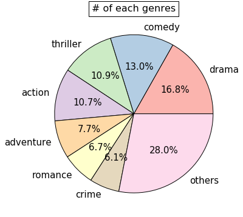

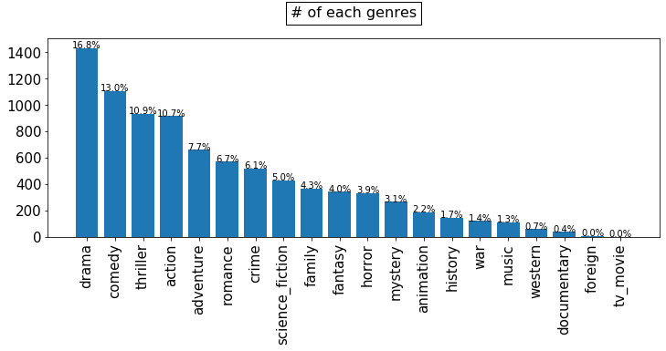

```python
f,ax=plt.subplots(figsize=(6,6))
pie_split(ax,dm.loc[:,Genres_sort.index].sum(),7);
ax.set_title('# of each genres',bbox={'facecolor':'white','pad':5},fontsize=16);


temp=dm.loc[:,Genres_sort.index].sum()
per=temp/temp.sum()
plt.figure(figsize=(12,4))
plt.bar(Genres_sort.index,Genres_sort.values);
plt.yticks(fontsize=15)
plt.xticks(rotation=90,fontsize=15);
plt.title('# of each genres',bbox={'facecolor':'white','pad':5},fontsize=16,y=1.08);

for i in range(len(per)):
    y=per.values[i]
    plt.text(i,Genres_sort.values[i],'{:0.1f}%'.format(per[i]*100),ha='center')
```

Drama has the most percentage in all the films, we shall use this result to define the rank of all the genres.

#### 4. The variation of variables with time

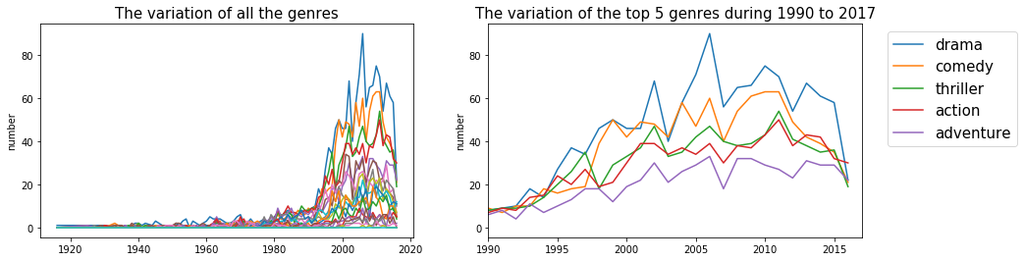

```python
fig=plt.figure(figsize=(15,4))
for i in Genres_sort.index:
    gr=dm.groupby('year')[i].sum()
    ax1=plt.subplot(121)
    ax1.plot(gr.index,gr.values,label=i)

for i in Genres_sort.index[0:5]:
    gr=dm.groupby('year')[i].sum()

    ax2=plt.subplot(122)
    ax2.plot(gr.index,gr.values,label=i)

ax1.set_title('The variation of all the genres',fontsize=15);
ax1.set_ylabel('number');

ax2.set_title('The variation of the top 5 genres during 1990 to 2017',fontsize=15);
ax2.set_xlim(1990,2017);
ax2.set_ylabel('number');
ax2.legend(bbox_to_anchor=(1.05,1.0),fontsize=15);
```

- All the films start to flourish after about 1990.
- According to the previous exploration of genres numbers, I take the top five genres during 1990-2017 and see their time-dependent variation. Although the `adventure` is always the lowest, other four genres have some competition (one wins another sometime).

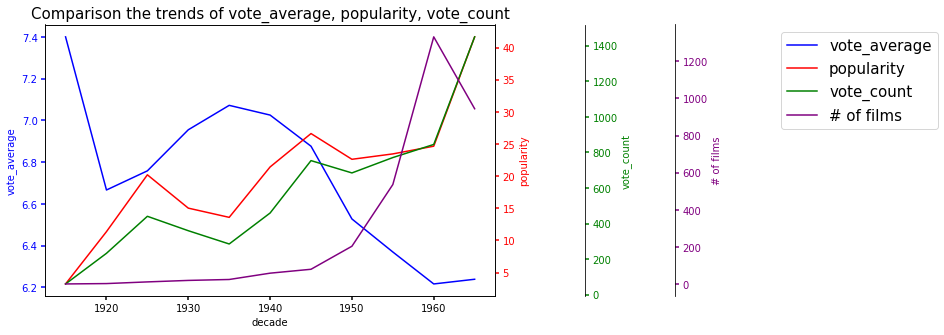

```python
def make_patch_spines_invisible(ax):
    ax.set_frame_on(True)
    ax.patch.set_visible(False)
    for sp in ax.spines.values():
        sp.set_visible(False)


fig, host = plt.subplots(figsize=(10,5))
fig.subplots_adjust(right=0.75)

par1 = host.twinx()
par2 = host.twinx()
par3 = host.twinx()

# Offset the right spine of par2.  The ticks and label have already been
# placed on the right by twinx above.
par2.spines["right"].set_position(("axes", 1.2))
par3.spines["right"].set_position(("axes", 1.4))
# Having been created by twinx, par2 has its frame off, so the line of its
# detached spine is invisible.  First, activate the frame but make the patch
# and spines invisible.
make_patch_spines_invisible(par2)
make_patch_spines_invisible(par3)
# Second, show the right spine.
par2.spines["right"].set_visible(True)
par3.spines["right"].set_visible(True)
p1, = host.plot(dm.groupby('decade')['vote_average'].mean(), "b-", label="vote_average")
p2, = par1.plot(dm.groupby('decade')['popularity'].mean(), "r-", label="popularity")
p3, = par2.plot(dm.groupby('decade')['vote_count'].mean(), "g-", label="vote_count")
p4, = par3.plot(dm.groupby('decade')['id'].count(),'purple',label='# of films')

host.set_xlabel("decade")
host.set_ylabel("vote_average")
par1.set_ylabel("popularity")
par2.set_ylabel("vote_count")
par3.set_ylabel('# of films')

host.yaxis.label.set_color(p1.get_color())
par1.yaxis.label.set_color(p2.get_color())
par2.yaxis.label.set_color(p3.get_color())
par3.yaxis.label.set_color(p4.get_color())

tkw = dict(size=4, width=1.5)
host.tick_params(axis='y', colors=p1.get_color(), **tkw)
par1.tick_params(axis='y', colors=p2.get_color(), **tkw)
par2.tick_params(axis='y', colors=p3.get_color(), **tkw)
par3.tick_params(axis='y', colors=p4.get_color(), **tkw)
host.tick_params(axis='x', **tkw)

lines = [p1, p2, p3, p4]

host.legend(lines, [l.get_label() for l in lines],bbox_to_anchor=(2,1.0),fontsize=15)
host.set_xticklabels(change_year(dm.groupby('decade')['vote_average'].mean()).index)
host.set_title('Comparison the trends of vote_average, popularity, vote_count',fontsize=15)
plt.show()
```

For the overall "film" industry, when the films increase, the participation of audience increases seen by the `vote_count` and the `popularity`. However, the `overall vote_average` of the films decrease.

#### 5. The relation within multiple variables

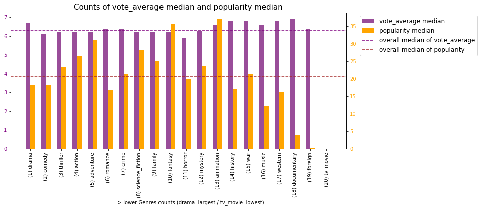

```python
gr=[];gr2=[];new_genres_list=[]
w=0.3
for n,i in enumerate(Genres_sort.index):
    try:
        temp=dm.groupby(i)['vote_average'].median()[1]
        temp2=dm.groupby(i)['popularity'].median()[1]

    except:
        temp=0;temp2=0

    new_genres_list.append('('+str(n+1)+') '+i)
    gr.append(temp)
    gr2.append(temp2)

x=np.arange(len(Genres_sort.index))
plt.figure(figsize=(12,5))
ax1=plt.subplot(1,1,1)
plt.xticks(x+w/2,new_genres_list,rotation=90);

vote=ax1.bar(x,gr,color=(0.6,0.3,0.6),width=w,align='center')

ax2=ax1.twinx()
pop=ax2.bar(x+w,gr2,color='orange',width=w,align='center')

mean_v=ax1.axhline(y=dm.vote_average.median(),color='purple',linestyle='--')
mean_p=ax2.axhline(y=dm.popularity.median(),color='brown',linestyle='--')

plt.legend([vote, pop,mean_v,mean_p],
           ['vote_average median', 'popularity median','overall median of vote_average','overall median of popularity']
           ,bbox_to_anchor=(1.4,1.0),fontsize=12);

ax1.tick_params(axis='y', labelcolor='purple')
ax2.tick_params(axis='y', labelcolor='orange')

plt.title('Counts of vote_average median and popularity median',fontsize=15);
ax1.set_xlabel('--------------> lower Genres counts (drama: largest / tv_movie: lowest)');
```

```python
# calculate the descriptive statistics
g_max={'revenue':[],'ratio':[],'budget':[]}
g_min={'revenue':[],'ratio':[],'budget':[]}
g_mean={'revenue':[],'ratio':[],'budget':[]}
g_median={'revenue':[],'ratio':[],'budget':[]}
g_75={'revenue':[],'ratio':[],'budget':[]}

for i in Genres_sort.index:
    for j in ['ratio','revenue','budget']:
        tmp=dm.groupby(i)[j]
        try:
            g_max[j].append(tmp.max()[1])
        except:
            g_max[j].append(0)
        try:
            g_min[j].append(tmp.min()[1])
        except:
            g_min[j].append(0)
        try:
            g_mean[j].append(tmp.mean()[1])
        except:
            g_mean[j].append(0)
        try:
            g_median[j].append(tmp.median()[1])
        except:
            g_median[j].append(0)
        try:
            g_75[j].append(tmp.quantile(0.75)[1])
        except:
            g_75[j].append(0)
```

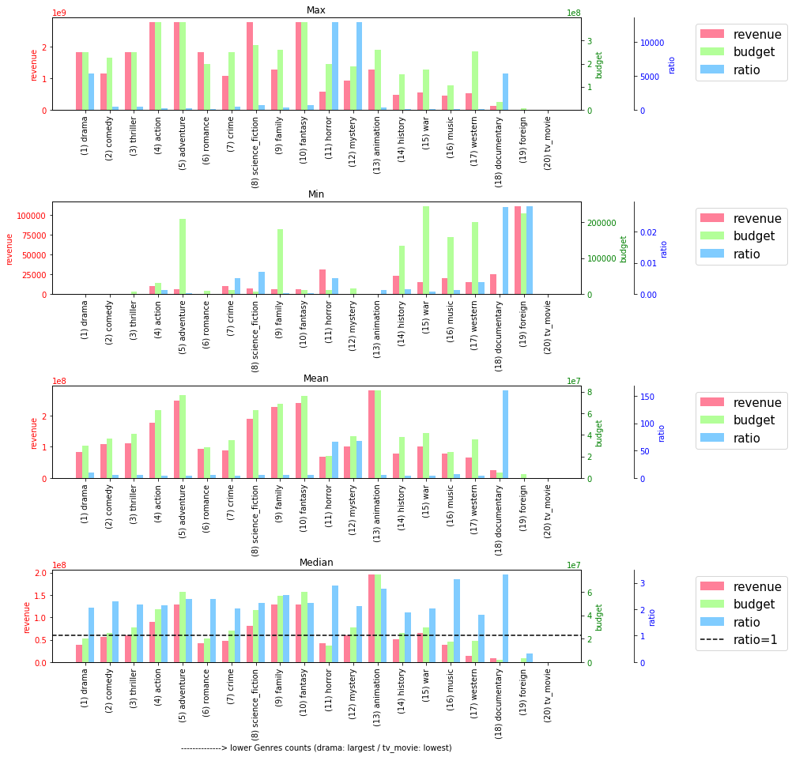

```python
def sub_plot_bar(ax1,ratio,revenue,budget,title,ratio_line=False):
    gr=ax1.bar(x,revenue,color=(1,0.5,0.6),width=w,align='center')

    ax2=ax1.twinx()
    gr2=ax2.bar(x+w,budget,color=(0.7,1,0.6),width=w,align='center')

    ax3=ax1.twinx()
    gr3=ax3.bar(x+2*w,ratio,color=(0.5,0.8,1),width=w,align='center')
    if ratio_line:
        line=ax3.axhline(y=1,color='k',linestyle='--')
        plt.legend([gr, gr2,gr3,line],['revenue', 'budget','ratio','ratio=1'],bbox_to_anchor=(1.4,1.0),fontsize=15);
    else:
        plt.legend([gr, gr2,gr3],['revenue', 'budget','ratio'],bbox_to_anchor=(1.4,1.0),fontsize=15);
    ax1.tick_params(axis='y', labelcolor='r')
    ax2.tick_params(axis='y', labelcolor='g')
    ax3.tick_params(axis='y', labelcolor='b')


    ax3.spines["right"].set_position(("axes", 1.1))
    make_patch_spines_invisible(ax3)
    ax3.spines["right"].set_visible(True)


    ax1.set_ylabel("revenue",color='r')
    ax2.set_ylabel("budget",color='g')
    ax3.set_ylabel("ratio",color='b')


    plt.title(title,fontsize=12)


x=np.arange(len(Genres_sort.index))*2
w=0.5

plt.figure(figsize=(12,15))

n=4
ax1=plt.subplot(n,1,1)
ax2=plt.subplot(n,1,2)
ax3=plt.subplot(n,1,3)
ax4=plt.subplot(n,1,4)
# ax5=plt.subplot(5,1,5)

plt.subplots_adjust(left=None, bottom=None, right=None, top=None, wspace=None, hspace=1)

sub_plot_bar(ax1,g_max['ratio'],g_max['revenue'],g_max['budget'],'Max')
sub_plot_bar(ax2,g_min['ratio'],g_min['revenue'],g_min['budget'],'Min')
sub_plot_bar(ax3,g_mean['ratio'],g_mean['revenue'],g_mean['budget'],'Mean')
sub_plot_bar(ax4,g_median['ratio'],g_median['revenue'],g_median['budget'],'Median',ratio_line=True)
# sub_plot_bar(ax5,g_75['ratio'],g_75['revenue'],g_75['budget'],'percentile = 75%',ratio_line=True)

ax1.set_xticks(x+w);ax1.set_xticklabels(new_genres_list,rotation=90);
ax2.set_xticks(x+w);ax2.set_xticklabels(new_genres_list,rotation=90);
ax3.set_xticks(x+w);ax3.set_xticklabels(new_genres_list,rotation=90);
ax4.set_xticks(x+w);ax4.set_xticklabels(new_genres_list,rotation=90);
# ax5.set_xticks(x+w);ax5.set_xticklabels(new_genres_list,rotation=90);
ax4.set_xlabel('--------------> lower Genres counts (drama: largest / tv_movie: lowest)');
```

- From the ratio, the `documentary` is more successful because it can earn many times than the budget (revenue >>> budget)
- The max ratio is in the `horror` and `mystery`, the min ratio is in the `documentary` and `foreign`
- The `drama` is rank 1, but its ratio is not the top one.

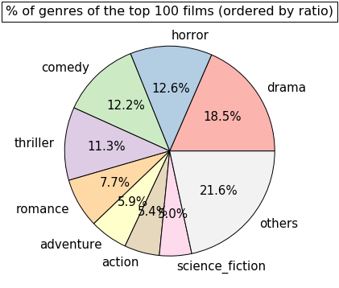

```python
# Construct Top 100 films by revenue
ratio_sort=dm.sort_values(by='ratio',ascending=False)
Top_100=ratio_sort.iloc[0:100]

f,ax=plt.subplots(figsize=(6,6),nrows=1, ncols=1)
pie_split(ax,Top_100.loc[:,Genres_sort.index].sum(),8);
ax.set_title('% of genres of the top 100 films (ordered by ratio)',bbox={'facecolor':'white','pad':5},fontsize=16);
```

When choosing the top 100 films which is ordered by ratio, the `drama` still has largest percentage.

```
Blue circle for Top 100 films
Red circle for each genres
Gray lines for median popularity and vote_average of overall films
Number in the titile is the rank for the genres counts in the overall films
```

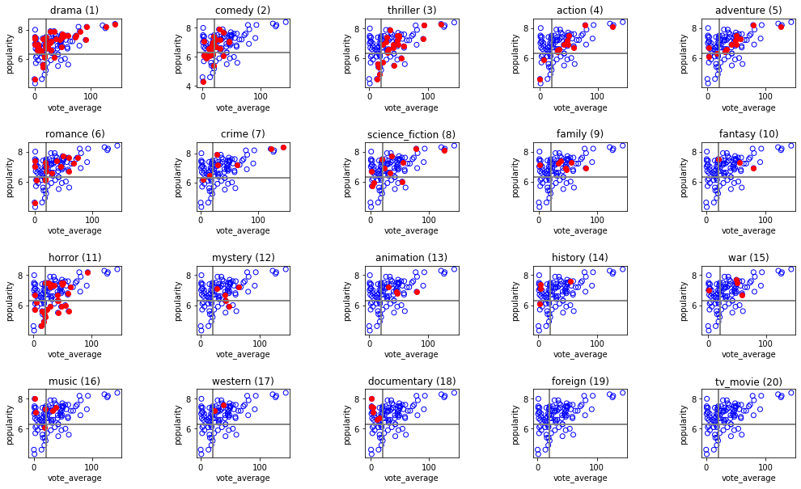

```python
plt.figure(figsize=(17,10))
plt.subplots_adjust(left=None, bottom=None, right=None, top=None, wspace=0.8, hspace=0.8)
print('Blue circle for Top 100 films')
print('Red circle for each genres')
print('Gray lines for median popularity and vote_average of overall films')
print('Number in the titile is the rank for the genres counts in the overall films')
for n,i in enumerate(Genres_sort.index):
    plt.subplot(4,5,n+1)
    plt.scatter(Top_100.popularity,Top_100.vote_average,facecolors='none',edgecolor='blue');
    plt.axvline(x=dm.popularity.median(),color='gray');
    plt.axhline(y=dm.vote_average.median(),color='gray');
    gdf=Top_100.query(i+'=="1"')
    plt.scatter(gdf.popularity,gdf.vote_average,color='r')
    plt.axvline(x=dm.popularity.median(),color='gray');
    plt.axhline(y=dm.vote_average.median(),color='gray');
    plt.title(i+' ('+str(n+1)+')')
    plt.xlabel('vote_average');plt.ylabel('popularity')
```

Although these films make most money, they don't guranttee the higher vote_average and popularity.

## Limitations

1. The specific calculation of popularity is uncertain.
2. The orders of the production_company and production_country are unknow, maybe it's not fair to just choose the first one.
3. The zero-budget (or <100) and zero-revenue might still have precious information of their vote_average, popularity and genres. Maybe the more complete data will change the results so far.
4. The record does not include the movies in the whole world. The movies in Asia and India are not the small targets to ignore.

## Reference

- https://www.kaggle.com/fabiendaniel/film-recommendation-engine
- https://stackoverflow.com/questions/19894939/calculate-arbitrary-percentile-on-pandas-groupby
- https://stackoverflow.com/questions/60138303/how-to-include-the-squared-symbol-in-a-graph-label
- https://stackoverflow.com/questions/21226868/superscript-in-python-plots
- https://stackoverflow.com/questions/34160169/kwargs-for-linestyle-and-linecolour-within-the-axvline-and-axhline-with-matplotl
- https://stackoverflow.com/questions/21034830/how-can-i-generate-more-colors-on-pie-chart-matplotlib
- https://stackoverflow.com/questions/6294179/how-to-find-all-occurrences-of-an-element-in-a-list
- https://datascience.stackexchange.com/questions/57853/group-small-values-in-a-pie-chart
- https://matplotlib.org/3.1.1/gallery/ticks_and_spines/multiple_yaxis_with_spines.html